# San Francisco Bicycle Racks Analysis

Franck Sombo

2024-12-13

# San Francisco Bicycle Racks Analysis

## Introduction

This report analyzes the bicycle parking racks dataset, focusing on three hypotheses:  
1. The number of bicycle parking racks installed has increased over time.  
2. Neighborhoods with higher population density or commercial activity have more racks installed.  
3. Bicycle racks are more frequently installed during certain months, aligning with cycling-friendly weather.

This analysis explores the bicycle rack installations across San Francisco, examining installation patterns, geographical distribution, and temporal trends. The data is sourced from San Francisco Open Data Portal.

The dataset contains information about public bicycle parking installations, including location details, installation dates, and capacity information. This analysis aims to:  
- Understand the spatial distribution of bicycle racks  
- Analyze installation trends over time  
- Identify patterns in rack placement and neighborhood distribution  
- Forecast future installation needs.

### Data Loading and Preview

|  | OBJECTID | ADDRESS | LOCATION | STREET | PLACEMENT | RACKS | SPACES | GLOBALID | INSTALL_YR | INSTALL_MO | LAT | LON | shape | data_as_of | data_loaded_at | analysis_neighborhood | supervisor_district | SF.Find.Neighborhoods.2 | Current.Police.Districts.2 | Current.Supervisor.Districts.2 | Analysis.Neighborhoods.2 | Analysis.Neighborhoods...2010.census.tracts.assigned.to.neighborhoods.2 | CBD..BID.and.GBD.Boundaries.as.of.2017.2 | Central.Market.Tenderloin.Boundary.Polygon...Updated.2 | Neighborhoods |
| --- | --- | --- | --- | --- | --- | --- | --- | --- | --- | --- | --- | --- | --- | --- | --- | --- | --- | --- | --- | --- | --- | --- | --- | --- | --- |
| 1 | 14108 | 342 30th Street |  | 30th Street | SIDEWALK | 4 | 8 |  | 2021 | 1 |  |  | POINT (-122.427470801 37.742048464) | 12/29/2021 16:46 | 6/17/2024 10:17 | Noe Valley | 8 | 84 | 9 | 5 | 22 | 174 |  |  | 84 |
| 2 | 12183 | Belden Street | Belden Place | BUSH | SIDEWALK | 2 | 4 |  | 2017 | 1 | 37.790909 | -122.403743 | POINT (-122.4037425 37.79090921) | 1/29/2020 12:38 | 6/17/2024 10:17 | Financial District/South Beach | 3 | 108 | 6 | 3 | 8 | 43 |  |  | 108 |
| 3 | 20813 | 1984 Mission Street | H&amp;R block | Mission Street | SIDEWALK | 1 | 2 |  | 2023 | 11 |  |  | POINT (-122.419769683 37.765347021) | 11/13/2023 15:31 | 6/17/2024 10:17 | Mission | 9 | 53 | 3 | 2 | 20 | 89 |  |  | 53 |
| 4 | 11638 | 2762 FOLSOM ST | Inglesia Zion | FOLSOM | SIDEWALK | 2 | 4 |  | 2011 | 3 | 37.753068 | -122.414474 | POINT (-122.414473796 37.753068005) | 1/29/2020 12:38 | 6/17/2024 10:17 | Mission | 9 | 53 | 3 | 2 | 20 | 166 |  |  | 53 |
| 5 | 12367 | 51 HAVELOCK ST | Balboa Park Swimming Pool | HAVELOCK | SIDEWALK | 2 | 4 |  | 2011 | 1 | 37.724767 | -122.44624 | POINT (-122.446239695 37.724766729) | 1/29/2020 12:38 | 6/17/2024 10:17 | Outer Mission | 11 | 94 | 9 | 1 | 28 | 186 |  |  | 94 |
| 6 | 11235 | 3300 BALBOA ST | Multicultural Preschool | BALBOA | SIDEWALK | 1 | 2 |  | 2014 | 7 | 37.776094 | -122.494286 | POINT (-122.494285682 37.776094239) | 1/29/2020 12:38 | 6/17/2024 10:17 | Outer Richmond | 1 | 8 | 8 | 4 | 29 | 56 |  |  | 8 |
| 7 | 10556 | 2991 SACRAMENTO ST | Liege Home and Garden | SACRAMENTO | SIDEWALK | 1 | 2 |  | 2002 | 0 | 37.78872399999999 | -122.441895 | POINT (-122.441894588 37.788724444) | 1/29/2020 12:38 | 6/17/2024 10:17 | Pacific Heights | 2 | 102 | 8 | 6 | 30 | 7 |  |  | 102 |
| 8 | 14212 | 2151 Laguna |  | Laguna | SIDEWALK | 3 | 6 |  | 2021 | 5 |  |  | POINT (-122.429175141 37.790921901) | 12/29/2021 16:46 | 6/17/2024 10:17 | Pacific Heights | 2 | 102 | 4 | 6 | 30 | 39 |  |  | 102 |
| 9 | 12493 | 548 Union Street | (former business) Cykel | Union Street | SIDEWALK | 1 | 2 |  | 2019 | 12 | 37.79941077 | -122.4174712 | POINT (-122.417471223 37.799410774) | 1/31/2020 14:21 | 6/17/2024 10:17 | Russian Hill | 3 | 107 | 6 | 6 | 32 | 15 |  |  | 107 |
| 10 | 12687 | 4113 4113 19th St |  | 4113 19th St | SIDEWALK | 2 | 4 |  | 2019 | 12 | 37.75926779 | -122.4350713 | POINT (-122.435071248 37.759267792) | 1/31/2020 14:21 | 6/17/2024 10:17 | Castro/Upper Market | 8 | 115 | 3 | 5 | 5 | 171 | 9 |  | 115 |

### Data Preparation

The dataset required cleaning to handle missing values and incorrect dates. By imputing or removing invalid entries and converting dates appropriately, the dataset is now suitable for detailed analysis, as minimal missing values will help to ensure reliable conclusions.

The dataset underwent several cleaning steps, including: - Standardized date formats using lubridate  
- Extracted coordinates from shape field  
- Removed records with missing installation years  
- Converted categorical variables to factors.  
Based on this, the data was cleaned and unwated columns removed to facilitate relevant analysis.

## Bicycle Racks Map

The map highlights the concentration of bicycle rack installations across San Francisco. Most racks are clustered in central and high-traffic areas, such as downtown and commercial zones, reflecting strategic placement to maximize accessibility and utility.

The interactive map reveals: - High concentration of racks in downtown and commercial areas  
- Clustering patterns along major transit corridors  
- Lower density in residential areas  
- Clear correlation with business districts.

### Interactive Map Visualization

[interactive chart not shown]

Fig.1 : Map of Bicycle Racks in San Francisco

[figure not shown]

(source: ©sftma.com)

## Descriptive Statistics

### Summary Statistics

|  | Variable | Sum | Mean | Median | StD |
| --- | --- | --- | --- | --- | --- |
| 1 | RACKS | 10336 | 1.712676056338028 | 1 | 4.713405892747619 |
| 2 | SPACES | 20583 | 3.410604805302403 | 2 | 4.713405892747619 |
| 3 | NEIGHBORHOODS | 301441 | 50.55190340432668 | 39 | 31.7225388480416 |

The dataset reveals a total installation of 10336 racks, averaging 1.7126761 racks per installation.

### Placement and Installation Types

|  | PLACEMENT | Total_racks | Total_spaces | No_of_locations |
| --- | --- | --- | --- | --- |
| 1 | SIDEWALK | 9027 | 17966 | 5867 |
| 2 | ROADWAY | 556 | 1152 | 101 |
| 3 | PARCEL | 372 | 719 | 34 |
| 4 | GARAGE | 255 | 494 | 25 |
| 5 | GARAGE CAGE | 108 | 216 | 2 |
| 6 |  | 9 | 18 | 3 |
| 7 | PARKLET | 7 | 14 | 2 |

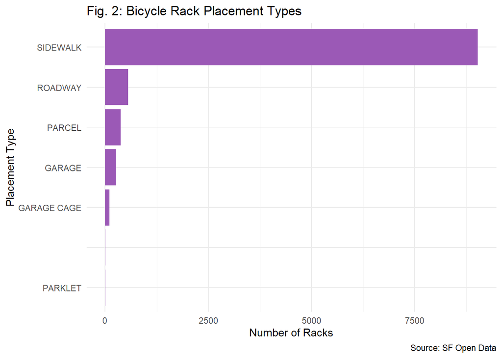

Sidewalk is by far the most common placement type of bicycle racks.

|  | INSTALL_YR | Total_installations | Standard_installations | Nonstandard_installations | Pct_standard |
| --- | --- | --- | --- | --- | --- |
| 1 | 2024 | 231 | 217 | 14 | 93.93939393939394 |
| 2 | 2023 | 367 | 166 | 201 | 45.23160762942779 |
| 3 | 2022 | 249 | 153 | 96 | 61.44578313253012 |
| 4 | 2021 | 369 | 181 | 188 | 49.05149051490515 |
| 5 | 2020 | 480 | 216 | 264 | 45 |
| 6 | 2019 | 414 | 245 | 169 | 59.17874396135265 |
| 7 | 2018 | 329 | 248 | 81 | 75.37993920972644 |
| 8 | 2017 | 341 | 190 | 151 | 55.71847507331378 |
| 9 | 2016 | 233 | 150 | 83 | 64.37768240343348 |
| 10 | 2015 | 511 | 237 | 274 | 46.37964774951076 |

[output cut: 16 more lines]

### Neighborhood Analysis

|  | analysis_neighborhood | Total_racks | Total_spaces | No_of_locations |
| --- | --- | --- | --- | --- |
| 1 | Mission | 1725 | 3502 | 1070 |
| 2 | Financial District/South Beach | 996 | 1988 | 499 |
| 3 | South of Market | 828 | 1640 | 421 |
| 4 | Sunset/Parkside | 536 | 1072 | 371 |
| 5 | Mission Bay | 504 | 885 | 120 |
| 6 | Hayes Valley | 432 | 863 | 273 |
| 7 | Tenderloin | 425 | 850 | 204 |
| 8 | Castro/Upper Market | 325 | 651 | 223 |
| 9 | Outer Richmond | 320 | 643 | 223 |
| 10 | Haight Ashbury | 316 | 632 | 217 |

[output cut: 31 more lines]

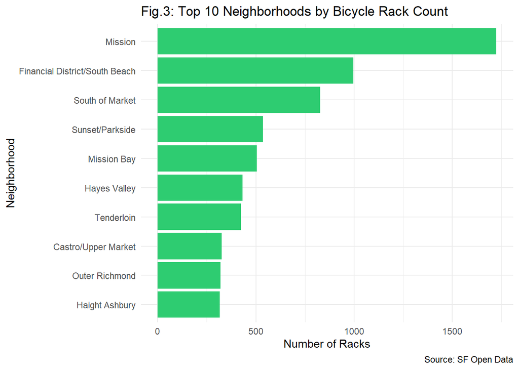

Top 3 neighborhoods account for more than 34% of total installations. Mission leads with 1725 racks.

### Racks installation over time

#### Annual Installation Trends

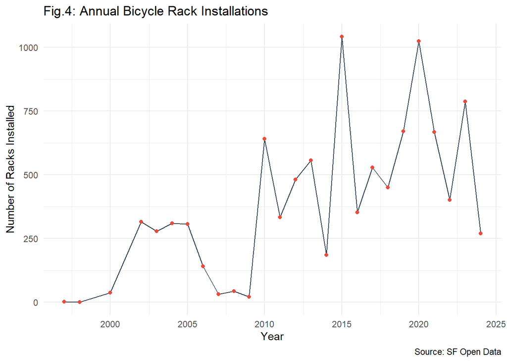

#### Monthly Installation Patterns

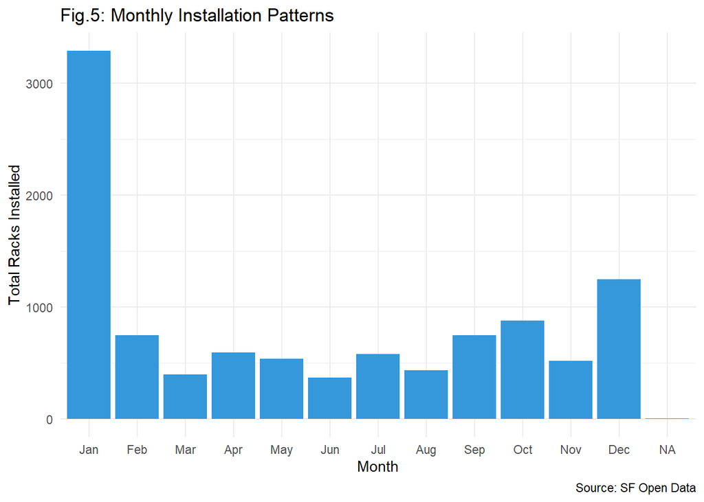

## Indepth Analysis

### Correlation Analysis

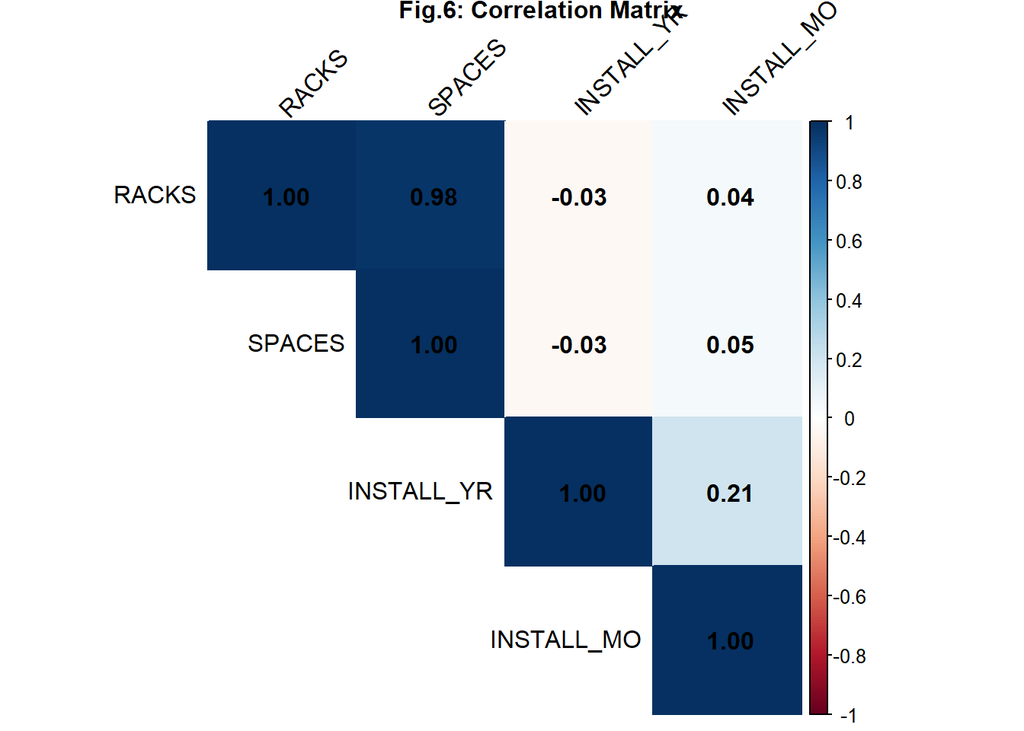

The correlation matrix reveals a strong positive relationship between racks and spaces, as expected. Temporal variables such as year and month show weaker correlations with installations, indicating uniform distribution trends across the dataset.

### Predictive Analysis

#### Time Series Forecasting

[figure not shown]

|  | Year | Predicted_Installations | Lower_CI_Installations | Upper_CI_Installations | Predicted_Spaces | Lower_CI_Spaces | Upper_CI_Spaces |
| --- | --- | --- | --- | --- | --- | --- | --- |
| 1 | 2024 | 312 | 21 | 603 | 1081 | 23 | 2140 |
| 2 | 2025 | 312 | 9 | 615 | 1081 | -22 | 2184 |
| 3 | 2026 | 312 | -3 | 627 | 1081 | -64 | 2227 |
| 4 | 2027 | 312 | -14 | 638 | 1081 | -106 | 2268 |
| 5 | 2028 | 312 | -25 | 649 | 1081 | -145 | 2307 |

## Conclusion & Recommendations

### Conclusion

The analysis of San Francisco’s bicycle rack installations provides valuable insights into spatial distribution, temporal trends, and neighborhood prioritization. The findings emphasize strategic placement in high-traffic areas, seasonality in installations, and alignment with urban sustainability goals. Recommendations include leveraging forecasting models for future planning and addressing underserved neighborhoods to enhance accessibility and encourage cycling across the city.

The Mission district leads by far with 1725 racks providing 3502 parking spaces across 1070 locations. Financial District/South Beach and South of Market follow as major hubs for bicycle parking. There’s a good distribution across residential areas like Sunset/Parkside. Mission Bay shows high density of racks relative to its locations (504 racks across 120).

This analysis provides insights into the distribution and characteristics of bicycle parking racks in San Francisco:  
1. The data shows the spatial distribution of bike racks across different neighborhoods  
2. We can observe installation trends over time  
3. Different placement types are analyzed  
4. The interactive map allows for exploration of specific locations.

### Recommendations

To optimize future installations, the city should analyze potential high-demand areas not yet served in cycling infrastructure, reinforcing the city’s commitment to sustainable transportation. Strategically, the city may consider establishing and operationalizing a 5-year plan with a maintenance and replacement to meet the increasing demand for cycling infrastructure.